# Simulation to Find Latent Variable Effects

Tianyi Liu

2023-07-14

```r
# source("a01_extended_dSVA.R")
source("s02_simulation_functions.R")
library(extraDistr)
library(statmod)
library(MASS)
library(dplyr)
library(tidyr)
library(statmod)
library(PCAtools)
set.seed(100)
```

## Simulations

We aim at finding a simulation parameter setting where latent variables can carry significant variations as compared to that carried by the regression parameters, such that using dSVA can prove to be beneficial.

$$\mathbf{Y}_{m \times n} = \mathbf{\Theta}_{m \times K} \mathbf{P}_{K
\times n} + \mathbf{Z}_{m \times p}\mathbf{D}_{p \times n} +
\mathbf{E}_{m \times n}, \\
\mathbf{P}_{K \times n} \geq 0, \\
\mathbf{P}_{K \times n}^T \mathbf{1}_K = \mathbf{1}_n.$$

- $n$: number of samples;
- $m$: number of genes ($m >> n$);
- $K$: number of cell types;
- $p$: number of hidden factors;
- $\lambda$: controls the gene expression cell-type specificity;
- $\gamma$: controls the elevated effects of the latent variable on marker genes.

### Case 1: random direction of latent variable

Create an error-free model $\mathbf{E} = \mathbf{0}$ first:

- $\mathbf{x}_j^T \sim \chi^2_{200} * \pi(W \cdot {\rm dir}(1, 1, \dots, 1) + (1 - W) \cdot {\rm dir}(\lambda, 1, \dots, 1) )$, $W \sim Ber(p_{\rm sig})$, and $\pi$ is a sampling operator;
- $\mathbf{p}_i \sim {\rm dir}(\alpha_{i1}, \dots, \alpha_{iK})$;
- $\mathbf{d}^T_1 = (0, \dots. 0, 1, \dots, 1)^T$ ($n/2$ $0$s and $1$s each).
- $z_{1j} \sim W * \chi^2_{\gamma \cdot 200} + (1 - W) * \chi^2_{200}$.

```
  D[1, ] <- c(rep(0, floor(n/2)), rep(1, ceiling(n/2)))
  Z[, 1] <- W * rchisq(n = m, df = gamma * 200) + (1 - W) * rchisq(n = m, df = 200)
```

Here, we model the situation where being in the latent group 1 (dummy variable value = 1) increases the expression of a gene to on average 2 times as high. If the gene is a marker genes, the expression is increased to $\gamma + 1$ times as high.

```r
n <- 20
m <- 1000
K <- 5
p <- 1
p_sig <- 0.5
lambda <- 5
gamma_seq <- 1:3
```

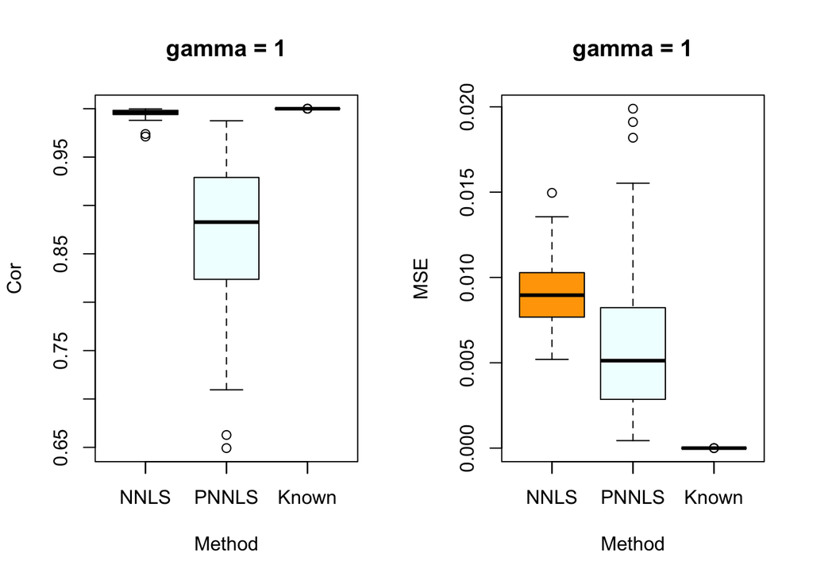

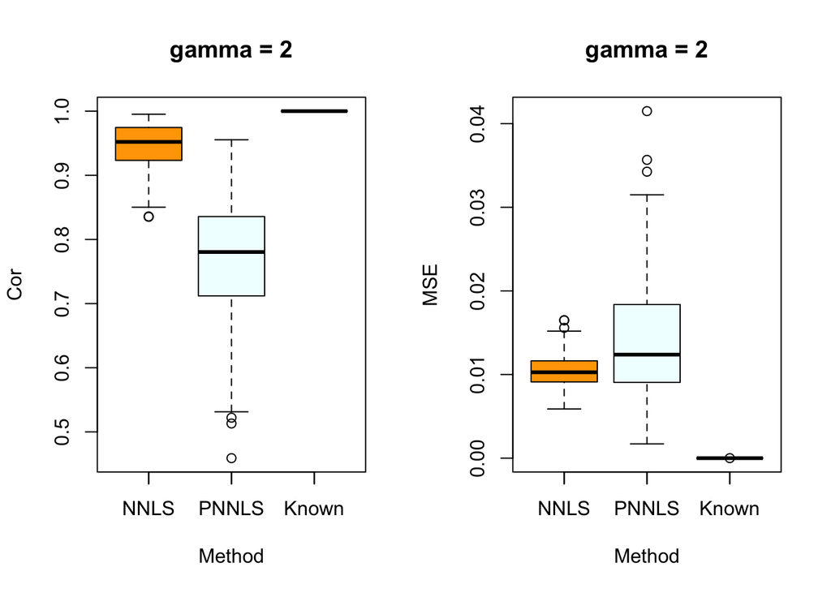

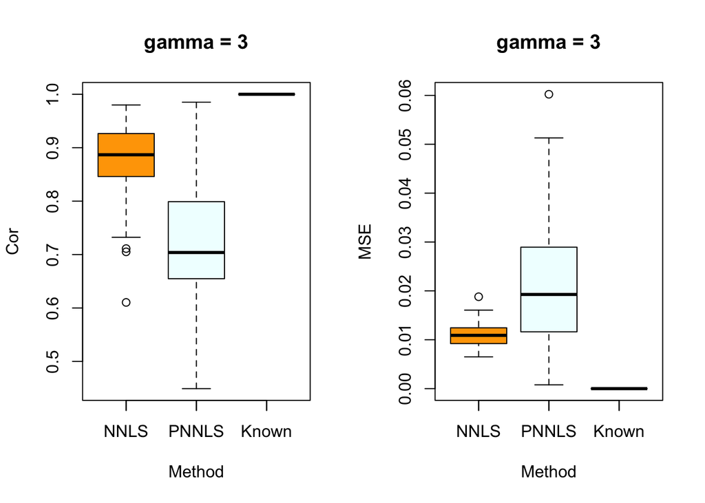

### Case 2: latent variable strengthens the expression of one cell type

- $\mathbf{z}_1 = \gamma * \mathbf{\theta}^*_1$.

[output not shown]

Let us assume that the latent variables increases the cell-type specific expression of Cell Type 1 to $\gamma$ times as high:

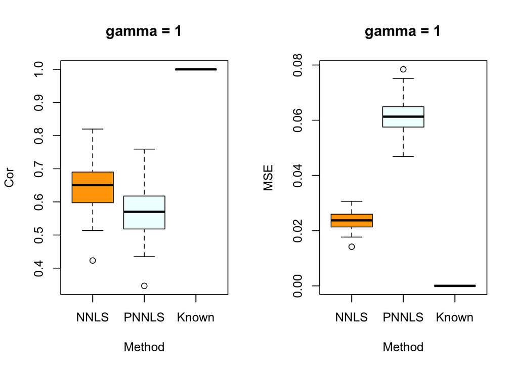

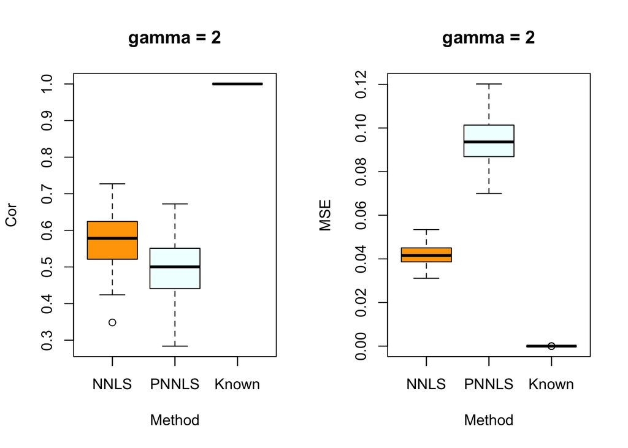

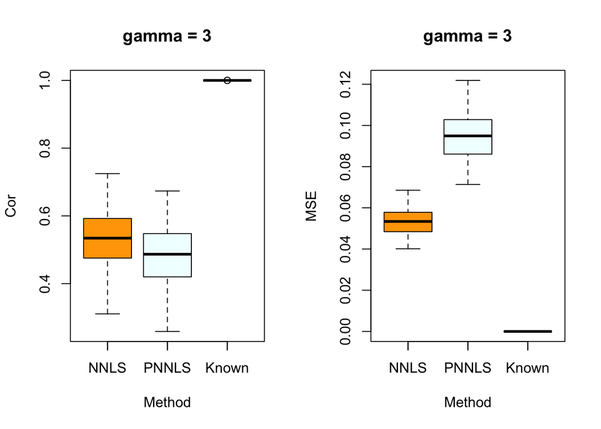

## The role of PCA (And Why Case 1 and 2?)

We can use a PCA plot to show that indeed, the one simulated latent variable captures a lot of variability:

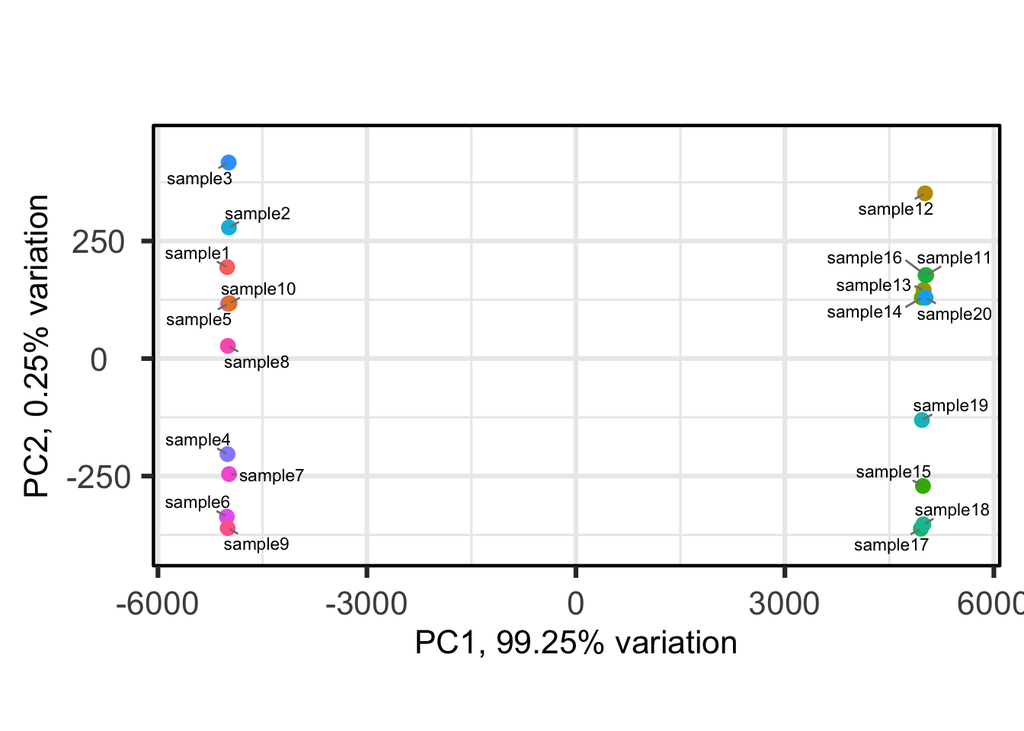

```r
## set parameters
n <- 20
m <- 1000
K <- 5
p <- 1
p_sig <- 0.5
lambda <- 5
gamma <- 2

## get one set of truths
true_data <- dSVA_model_sim_2(m, n, K, p, p_sig, lambda, gamma)
colnames(true_data$Y) <- paste0("sample", 1:ncol(true_data$Y))
metadat <- tibble(group = c(rep("A", floor(n/2)), rep("B", ceiling(n/2))),
                  names = colnames(true_data$Y))
rownames(metadat) <- colnames(true_data$Y)
Y_pca <- PCAtools::pca(mat = true_data$Y, metadata = metadat, removeVar = 0.1)
PCAtools::biplot(pcaobj = Y_pca)
```

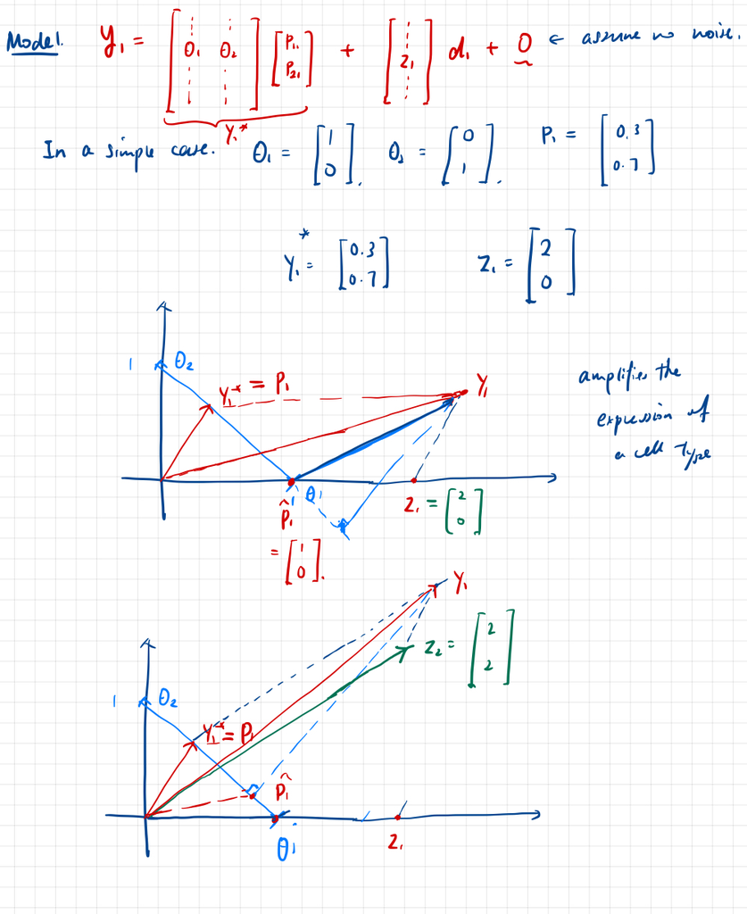